# brewsTest

Kebur Fantahun

02/21/2021

# Introduction

## Restatment of problem

# Libraries

```r
library(tidyverse)
library(magrittr)
library(knitr)
library(rmarkdown)
library(DT)
library(mice)
library(VIM)
library(psych)
library(tidyverse)
library (readr)
```

# Utility functions

```r
isEmpty <- function(column) {
    is.na(column) | column == 0 | column == "" | column == " " | column == "NA" | column == "na" | column == "Na" | column == "nA" | column == "NaN"
}
```

# Import Data

```r
beer_url="https://raw.githubusercontent.com/RiccoFerraro/dds_case_study_1/main/Beers.csv?token=AJ6R3O5PU6YT2DDEIUZTQ5DAHIFFU"
brewery_url="https://raw.githubusercontent.com/RiccoFerraro/dds_case_study_1/main/Breweries.csv?token=AJ6R3O6A7SJRNWAGTPCHSWLAHIFFY"

beer <-read_csv(url(beer_url))
brew <-read_csv(url(brewery_url))
```

*Note: we use the merge data in Question 1 and therefor we need to perform step 2 first.* # 2. Merge beer data first with the breweries data & Print first 6 and last 6 oservations in merged file.

```r
## EDA: Formatting, and dealing with NA's

# beer$Brewery_id
# names(beer)[names(beer) == "Brewery_id"] <- "Brew_ID"

bdat = merge(beer, brew, by.x = "Brewery_id", by.y = "Brew_ID")
names(bdat)[names(bdat) == "Name.x"] <- "Drink_name"
names(bdat)[names(bdat) == "Name.y"] <- "Brewery"

kable(head(bdat))
```

| Brewery_id | Drink_name | Beer_ID | ABV | IBU | Style | Ounces | Brewery | City | State |
| --- | --- | --- | --- | --- | --- | --- | --- | --- | --- |
| 1 | Get Together | 2692 | 0.045 | 50 | American IPA | 16 | NorthGate Brewing | Minneapolis | MN |
| 1 | Maggie’s Leap | 2691 | 0.049 | 26 | Milk / Sweet Stout | 16 | NorthGate Brewing | Minneapolis | MN |
| 1 | Wall’s End | 2690 | 0.048 | 19 | English Brown Ale | 16 | NorthGate Brewing | Minneapolis | MN |
| 1 | Pumpion | 2689 | 0.060 | 38 | Pumpkin Ale | 16 | NorthGate Brewing | Minneapolis | MN |
| 1 | Stronghold | 2688 | 0.060 | 25 | American Porter | 16 | NorthGate Brewing | Minneapolis | MN |
| 1 | Parapet ESB | 2687 | 0.056 | 47 | Extra Special / Strong Bitter (ESB) | 16 | NorthGate Brewing | Minneapolis | MN |

```r
kable(tail(bdat))
```

|  | Brewery_id | Drink_name | Beer_ID | ABV | IBU | Style | Ounces | Brewery | City | State |
| --- | --- | --- | --- | --- | --- | --- | --- | --- | --- | --- |
| 2405 | 556 | Pilsner Ukiah | 98 | 0.055 | NA | German Pilsener | 12 | Ukiah Brewing Company | Ukiah | CA |
| 2406 | 557 | Heinnieweisse Weissebier | 52 | 0.049 | NA | Hefeweizen | 12 | Butternuts Beer and Ale | Garrattsville | NY |
| 2407 | 557 | Snapperhead IPA | 51 | 0.068 | NA | American IPA | 12 | Butternuts Beer and Ale | Garrattsville | NY |
| 2408 | 557 | Moo Thunder Stout | 50 | 0.049 | NA | Milk / Sweet Stout | 12 | Butternuts Beer and Ale | Garrattsville | NY |
| 2409 | 557 | Porkslap Pale Ale | 49 | 0.043 | NA | American Pale Ale (APA) | 12 | Butternuts Beer and Ale | Garrattsville | NY |
| 2410 | 558 | Urban Wilderness Pale Ale | 30 | 0.049 | NA | English Pale Ale | 12 | Sleeping Lady Brewing Company | Anchorage | AK |

# 1. How many breweries are in each state?

See Table:

```r
bdat$State = as.factor(bdat$State)
brewNum = bdat %>%
  filter(!is.na(bdat) & !is.na(Brewery_id)) %>%
  group_by(State) %>% summarize(unique_breweries=length(unique(Brewery_id)))
datatable(brewNum)
```

|  | State | unique_breweries |
| --- | --- | --- |
| 1 | AK | 7 |
| 2 | AL | 3 |
| 3 | AR | 2 |
| 4 | AZ | 11 |
| 5 | CA | 39 |
| 6 | CO | 47 |
| 7 | CT | 8 |
| 8 | DC | 1 |
| 9 | DE | 2 |
| 10 | FL | 15 |

[output cut: 41 more lines]

```r
print("Total Unique Breweries: ")
```

```
## [1] "Total Unique Breweries: "
```

```r
sum(brewNum$unique_breweries)
```

```
## [1] 558
```

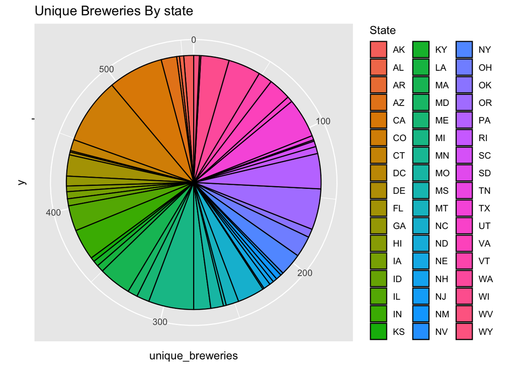

```r
brewNum %>%  ggplot(aes(x=unique_breweries, y="",fill=State)) + geom_bar(stat = "identity", colour="black") + coord_polar("x", start=0) + ggtitle("Unique Breweries By state")
```

# 3a. Plot missing data for reference

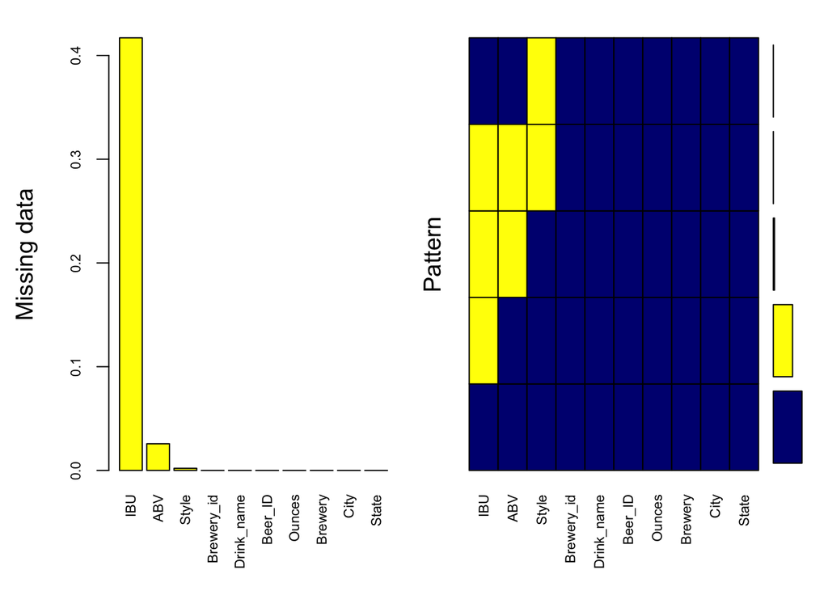

```
##
##  Variables sorted by number of missings:
##    Variable       Count
##         IBU 0.417012448
##         ABV 0.025726141
##       Style 0.002074689
##  Brewery_id 0.000000000
##  Drink_name 0.000000000
##     Beer_ID 0.000000000
##      Ounces 0.000000000
##     Brewery 0.000000000
##        City 0.000000000
##       State 0.000000000
```

```r
# Plot missing data (there should be none)
bdat_mice_clean <- aggr(bdat, col=c('navyblue','yellow'),
                    numbers=TRUE, sortVars=TRUE,
                    labels=names(bdat), cex.axis=.7,
                    gap=3, ylab=c("Missing data","Pattern"))
```

```r
summary(bdat)
```

```
##    Brewery_id     Drink_name           Beer_ID            ABV
##  Min.   :  1.0   Length:2410        Min.   :   1.0   Min.   :0.00100
##  1st Qu.: 94.0   Class :character   1st Qu.: 808.2   1st Qu.:0.05000
##  Median :206.0   Mode  :character   Median :1453.5   Median :0.05600
##  Mean   :232.7                      Mean   :1431.1   Mean   :0.05977
##  3rd Qu.:367.0                      3rd Qu.:2075.8   3rd Qu.:0.06700
##  Max.   :558.0                      Max.   :2692.0   Max.   :0.12800
##                                                      NA's   :62
##       IBU            Style               Ounces        Brewery
##  Min.   :  4.00   Length:2410        Min.   : 8.40   Length:2410
##  1st Qu.: 21.00   Class :character   1st Qu.:12.00   Class :character
##  Median : 35.00   Mode  :character   Median :12.00   Mode  :character
##  Mean   : 42.71                      Mean   :13.59
##  3rd Qu.: 64.00                      3rd Qu.:16.00
##  Max.   :138.00                      Max.   :32.00
##  NA's   :1005
##      City               State
##  Length:2410        CO     : 265
##  Class :character   CA     : 183
##  Mode  :character   MI     : 162
##                     IN     : 139
##                     TX     : 130
##                     OR     : 125
##                     (Other):1406
```

# 3b. Assess missing data when no data exists for IBU OR ABV

1. Special Release, The Crowler^tm, Can’d aid foundation are missing ABV/IBU/Style
2. Cedar creek - Special Release is ambiguous, missing ABV/IBU/Style and will be dropped as it does not solve the QOI.
3. Oskar Blues Brewery - The Crowler is not an actual beer but a type of can
4. Oskar Blues Brewery - Can’d aid foundation is a relief effort that sends water so it does not fit in the dataset.
5. Beer ID 2364, Royal Lager of Weston Brewing has no ABV/IBU
6. Same for BID - 2322 Fort Pitt Brewing Company Fort Pitt Ale
7. Oskar Blues Brewery Birth IPA, 1750
8. 710, no data
9. MillKing It Productions AXL Pale Ale, 273 - out of business no info
10. 1095 no data
11. 963 no data

```r
# the following line removes these NA points
bdat_clean <- bdat %>% filter(bdat$Beer_ID!=2210 & bdat$Beer_ID!=1796 & bdat$Beer_ID!=1790 & bdat$Beer_ID!=2364&
bdat$Beer_ID!=2322& bdat$Beer_ID!=1750& bdat$Beer_ID!=710& bdat$Beer_ID!=273& bdat$Beer_ID!=1095& bdat$Beer_ID!=963)
```

# 3c. Enter in missing data when by hand when data is availbe publicly

-Add style data for 2527 and 1635 by looking it up by hand. -Add IBU and ABV Data for many missing rows by looking up by hand (online via `BeerAdvocate.com` or `Untappd.com`)

```r
imputeMissingStyle <- function(beer_id, style){
    if(beer_id=="2527"){
    style = "Scottish-Style Amber Ale"
  }
    if(beer_id=="1635"){
    style = "Lager"
    }
  style
}

# Update ABV and IBU for NA's; to hand selected data use  %>% select(Beer_ID, Brewery, Drink_name, ABV, IBU)
bdat_hand_updated <-bdat_clean %>%
    filter(is.na(ABV) & is.na(IBU)) %>% rows_update(tibble(Beer_ID = c(2382, 2381, 1948, 1347, 2595, 1163, 940, 2490, 2489, 2488, 2487, 2472, 779, 364, 60, 59, 58, 57, 652, 2344, 2342, 1752, 61, 1724, 774, 121, 1784, 1541, 1025, 219, 307, 1096, 1056, 944, 731, 870, 869, 868, 867, 763, 504, 524, 450, 449, 448, 447, 446, 520, 506, 142, 335, 64), ABV = c(0.075, 0.055, 0.045, 0.060, 0.062, 0.0499, 0.06, 0.061, 0.038, 0.057, 0.051, 0.055, 0.05, 0.07, 0.052, 0.05, 0.049, 0.051, 0.07, 0.055, 0.049, 0.07, 0.052, 0.07, 0.058, 0.052, 0.07, 0.052, 0.086, 0.051, 0.06, 0.062, 0.055, 0.05, 0.055, 0.042, 0.05, 0.045, 0.039, 0.052, 0.072, 0.045, 0.061, 0.064, 0.058, 0.049, 0.05, 0.042, 0.05, 0.065, 0.065, 0.05), IBU = c(NA, 3.57, 65, 23, NA, 15, NA, 40, 7, 32, 35, NA, 5, NA, NA, NA, NA, NA, 80, NA, NA, NA, 28, NA, NA, 12, 40, 21, 80, NA, 38, NA, NA, 25, NA, NA, NA, NA, NA, NA, NA, NA, NA, NA, NA, NA, NA, NA, NA, NA, 70, 17)))
```

```
## Matching, by = "Beer_ID"
```

```r
bdat_with_hand_updates = merge(bdat_hand_updated,bdat_clean,by="Beer_ID",all.y = TRUE) %>% rowwise %>% mutate(Brewery_id=Brewery_id.y, Drink_name=Drink_name.y, Ounces
=Ounces.y, Brewery=Brewery.y, City=City.y, State=State.y, Style = imputeMissingStyle(Beer_ID, Style.y),IBU = if_else(isEmpty(IBU.y), IBU.x, IBU.y), ABV = if_else(isEmpty(ABV.y), ABV.x, ABV.y)) %>% select(Brewery_id, ABV, IBU, Drink_name, Style, Ounces, Brewery, City, State)
```

# 3d. Assess and impute missing IBU data with median IBU by style

```r
#Summary stats before imputation
kable(summary(bdat_with_hand_updates))
```

|  | Brewery_id | ABV | IBU | Drink_name | Style | Ounces | Brewery | City | State |
| --- | --- | --- | --- | --- | --- | --- | --- | --- | --- |
|  | Min. : 1.0 | Min. :0.00100 | Min. : 3.57 | Length:2400 | Length:2400 | Min. : 8.40 | Length:2400 | Length:2400 | CO : 261 |
|  | 1st Qu.: 94.0 | 1st Qu.:0.05000 | 1st Qu.: 21.00 | Class :character | Class :character | 1st Qu.:12.00 | Class :character | Class :character | CA : 183 |
|  | Median :206.5 | Median :0.05600 | Median : 35.00 | Mode :character | Mode :character | Median :12.00 | Mode :character | Mode :character | MI : 161 |
|  | Mean :232.6 | Mean :0.05969 | Mean : 42.59 | NA | NA | Mean :13.58 | NA | NA | IN : 139 |
|  | 3rd Qu.:367.0 | 3rd Qu.:0.06700 | 3rd Qu.: 64.00 | NA | NA | 3rd Qu.:16.00 | NA | NA | TX : 129 |
|  | Max. :558.0 | Max. :0.12800 | Max. :138.00 | NA | NA | Max. :32.00 | NA | NA | OR : 125 |
|  | NA | NA | NA’s :976 | NA | NA | NA | NA | NA | (Other):1402 |

```r
# Impute IBU
bdat.IBU.Summary <- bdat_with_hand_updates %>% filter(!isEmpty(IBU)) %>% group_by(Style) %>% summarise(median_IBU_by_style=median(IBU))
bdat.imputed.IBU <-merge(bdat_with_hand_updates, bdat.IBU.Summary, by="Style")  %>% mutate(IBU.clean = if_else(isEmpty(IBU), median_IBU_by_style, as.double(IBU)))
bdat.imputed.IBU.clean = bdat.imputed.IBU[,-c(4)]
bdat.imputed.IBU.clean %>% filter(isEmpty(Style))
```

```
##  [1] Style               Brewery_id          ABV
##  [4] Drink_name          Ounces              Brewery
##  [7] City                State               median_IBU_by_style
## [10] IBU.clean
## <0 rows> (or 0-length row.names)
```

```r
# Summary stats after imputation
kable(summary(bdat.imputed.IBU.clean))
```

|  | Style | Brewery_id | ABV | Drink_name | Ounces | Brewery | City | State | median_IBU_by_style | IBU.clean |
| --- | --- | --- | --- | --- | --- | --- | --- | --- | --- | --- |
|  | Length:2348 | Min. : 1 | Min. :0.02700 | Length:2348 | Min. : 8.40 | Length:2348 | Length:2348 | CO : 258 | Min. : 8.00 | Min. : 3.57 |
|  | Class :character | 1st Qu.: 92 | 1st Qu.:0.05000 | Class :character | 1st Qu.:12.00 | Class :character | Class :character | CA : 181 | 1st Qu.:21.00 | 1st Qu.: 21.00 |
|  | Mode :character | Median :204 | Median :0.05600 | Mode :character | Median :12.00 | Mode :character | Mode :character | MI : 146 | Median :30.00 | Median : 32.00 |
|  | NA | Mean :231 | Mean :0.05967 | NA | Mean :13.56 | NA | NA | IN : 139 | Mean :40.03 | Mean : 40.46 |
|  | NA | 3rd Qu.:366 | 3rd Qu.:0.06700 | NA | 3rd Qu.:16.00 | NA | NA | TX : 129 | 3rd Qu.:69.00 | 3rd Qu.: 60.00 |
|  | NA | Max. :558 | Max. :0.12800 | NA | Max. :32.00 | NA | NA | OR : 115 | Max. :96.00 | Max. :138.00 |
|  | NA | NA | NA | NA | NA | NA | NA | (Other):1380 | NA | NA |

# 3e. Plot missing data to show it has all been resolved.

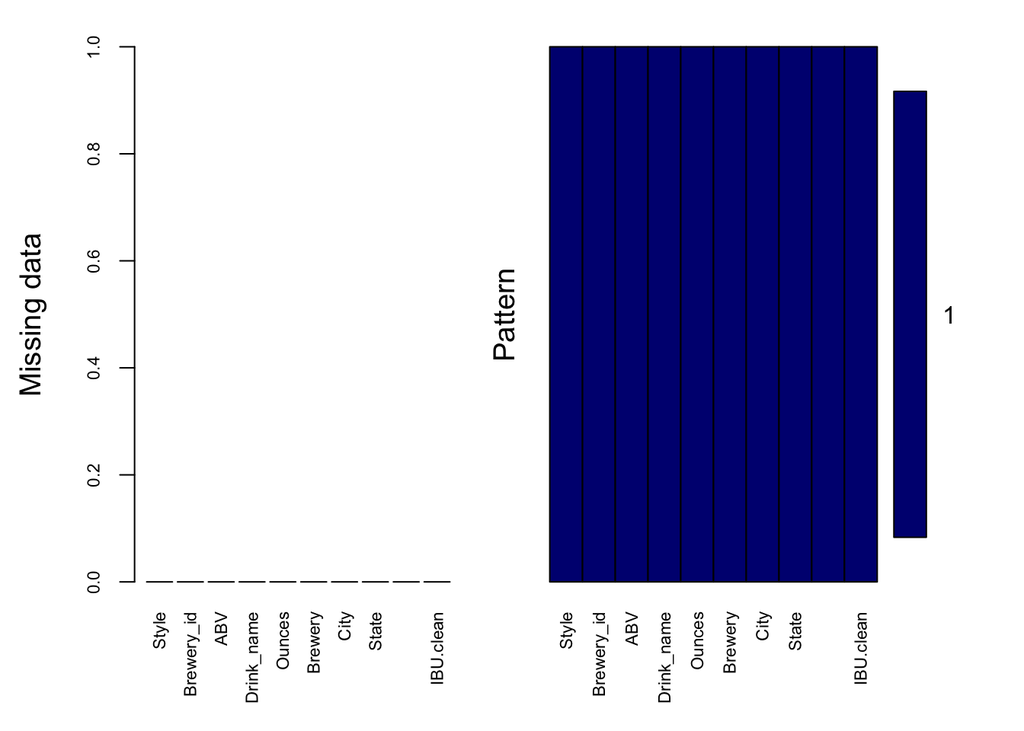

```
##
##  Variables sorted by number of missings:
##             Variable Count
##                Style     0
##           Brewery_id     0
##                  ABV     0
##           Drink_name     0
##               Ounces     0
##              Brewery     0
##                 City     0
##                State     0
##  median_IBU_by_style     0
##            IBU.clean     0
```

```r
# Plot missing data (there should be none)
bdat_mice_clean <- aggr(bdat.imputed.IBU.clean, col=c('navyblue','yellow'),
                    numbers=TRUE, sortVars=TRUE,
                    labels=names(bdat.imputed.IBU.clean), cex.axis=.7,
                    gap=3, ylab=c("Missing data","Pattern"))
```

```r
summary(bdat.imputed.IBU.clean)
```

```
##     Style             Brewery_id       ABV           Drink_name
##  Length:2348        Min.   :  1   Min.   :0.02700   Length:2348
##  Class :character   1st Qu.: 92   1st Qu.:0.05000   Class :character
##  Mode  :character   Median :204   Median :0.05600   Mode  :character
##                     Mean   :231   Mean   :0.05967
##                     3rd Qu.:366   3rd Qu.:0.06700
##                     Max.   :558   Max.   :0.12800
##
##      Ounces        Brewery              City               State
##  Min.   : 8.40   Length:2348        Length:2348        CO     : 258
##  1st Qu.:12.00   Class :character   Class :character   CA     : 181
##  Median :12.00   Mode  :character   Mode  :character   MI     : 146
##  Mean   :13.56                                         IN     : 139
##  3rd Qu.:16.00                                         TX     : 129
##  Max.   :32.00                                         OR     : 115
##                                                        (Other):1380
##  median_IBU_by_style   IBU.clean
##  Min.   : 8.00       Min.   :  3.57
##  1st Qu.:21.00       1st Qu.: 21.00
##  Median :30.00       Median : 32.00
##  Mean   :40.03       Mean   : 40.46
##  3rd Qu.:69.00       3rd Qu.: 60.00
##  Max.   :96.00       Max.   :138.00
##
```